# Practice notebook for univariate analysis using NHANES data

This notebook will give you the opportunity to perform some univariate analysis on your own using the NHANES. These analysis are similar to what was done in the week 2 NHANES case study notebook.

You can enter your code into the cells that say "enter your code here", and you can type responses to the questions into the cells that say "Type Markdown and Latex".

Note that most of the code that you will need to write below is very similar to code that appears in the case study notebook. You will need to edit code from that notebook in small ways to adapt it to the prompts below.

To get started, we will use the same module imports and read the data in the same way as we did in the case study:

```python
%matplotlib inline
import matplotlib.pyplot as plt
import seaborn as sns
import pandas as pd
import statsmodels.api as sm
import numpy as np

da = pd.read_csv("nhanes_2015_2016.csv")
```

## Question 1

Relabel the marital status variable DMDMARTL to have brief but informative character labels. Then construct a frequency table of these values for all people, then for women only, and for men only. Then construct these three frequency tables using only people whose age is between 30 and 40.

```python
# insert your code here
da["DMDMARTLx"] = da.DMDMARTL.replace({1: "Married", 2: "Widowed", 3: "Divorced", 4: "Separated", 5: "Never married",
                                       6: "Living with partner", 77: "Refused", 99: "Don't Know"})
da["DMDMARTLx"] = da.DMDMARTLx.fillna("Missing")
x = da.DMDMARTLx.value_counts()
x / x.sum()
```

```
Married                0.484743
Never married          0.175065
Divorced               0.100959
Living with partner    0.091892
Widowed                0.069050
Missing                0.045510
Separated              0.032432
Refused                0.000349
Name: DMDMARTLx, dtype: float64
```

```python
print(da.DMDMARTLx.value_counts().sum())
print(da.shape)
pd.isnull(da.DMDMARTLx).sum()
```

```
5735
(5735, 29)
```

```
0
```

```python
da["RIAGENDRx"] = da.RIAGENDR.replace({1: "Male", 2: "Female"})
da.RIAGENDRx.value_counts()
```

```
Female    2976
Male      2759
Name: RIAGENDRx, dtype: int64
```

```python
da["DMDMARTLx"] = da.DMDMARTL.replace({1: "Married", 2: "Widowed", 3: "Divorced", 4: "Separated", 5: "Never married",
                                       6: "Living with partner", 77: "Refused", 99: "Don't Know"})
da["DMDMARTLx"] = da.DMDMARTLx.fillna("Missing")
da["RIAGENDRx"] = da.RIAGENDR.replace({1: "Male", 2: "Female"})
x = da.groupby(["RIAGENDRx"])["DMDMARTLx"].value_counts()
x / x.sum()
```

```
RIAGENDRx  DMDMARTLx
Female     Married                0.227201
           Never married          0.090671
           Divorced               0.061029
           Widowed                0.051613
           Living with partner    0.045684
           Missing                0.021970
           Separated              0.020575
           Refused                0.000174
Male       Married                0.257541
           Never married          0.084394
           Living with partner    0.046207
           Divorced               0.039930
           Missing                0.023540
           Widowed                0.017437
           Separated              0.011857
           Refused                0.000174
Name: DMDMARTLx, dtype: float64
```

```python
da["agegrp"] = pd.cut(da.RIDAGEYR, [30, 40])
da["RIAGENDRx"] = da.RIAGENDR.replace({1: "Male", 2: "Female"})
da["DMDMARTLx"] = da.DMDMARTL.replace({1: "Married", 2: "Widowed", 3: "Divorced", 4: "Separated", 5: "Never married",
                                       6: "Living with partner", 77: "Refused", 99: "Don't Know"})
da["DMDMARTLx"] = da.DMDMARTLx.fillna("Missing")
x = da.groupby(["agegrp", "RIAGENDRx"])["DMDMARTLx"].value_counts()
x / x.sum()
```

```
agegrp    RIAGENDRx  DMDMARTLx
(30, 40]  Female     Married                0.276824
                     Never married          0.104077
                     Living with partner    0.061159
                     Divorced               0.046137
                     Separated              0.018240
                     Widowed                0.002146
          Male       Married                0.276824
                     Never married          0.095494
                     Living with partner    0.077253
                     Divorced               0.025751
                     Separated              0.012876
                     Widowed                0.002146
                     Refused                0.001073
Name: DMDMARTLx, dtype: float64
```

**Q1a.** Briefly comment on some of the differences that you observe between the distribution of marital status between women and men, for people of all ages.

**Q1b.** Briefly comment on the differences that you observe between the distribution of marital status states for women between the overall population, and for women between the ages of 30 and 40.

**Q1c.** Repeat part b for the men.

## Question 2

Restricting to the female population, stratify the subjects into age bands no wider than ten years, and construct the distribution of marital status within each age band. Within each age band, present the distribution in terms of proportions that must sum to 1.

```python
import pandas as pd

da = pd.read_csv("nhanes_2015_2016.csv")
# recode marital status and gender so that they're treated as categorical
da['DMDMARTLx'] = da.DMDMARTL.replace({1: 'Married', 2: 'Widowed', 3: 'Divorced', 4: 'Separated', 5: 'Never Married',
                                       6: 'Living with Partner', 77: 'Refused', 99: 'Don\'t Know'})
da['RIAGENDRx'] = da.RIAGENDR.replace({1: 'Male', 2: 'Female'})

# subset the data to include only females
da = da.where(da.RIAGENDRx == 'Female')
# cut age into bands no wider than 10 years
da['agegrp'] = pd.cut(da.RIDAGEYR, [0, 20, 30, 40, 50, 60, 70, 80])
# Eliminate rare/missing values
dx = da.loc[~da.DMDMARTLx.isin(["Don't know", "Missing"]), :]
# group marital status by age group band
dx = dx.groupby(["agegrp"])["DMDMARTLx"]
# obtain the counts for marital status within each age group band
dx = dx.value_counts()

dx = dx.unstack() # Restructure the results from 'long' to 'wide'
dx = dx.apply(lambda x: x/x.sum(), axis=1) # Normalize within each stratum to get proportions
print(dx.to_string(float_format="%.2f"))  # Limit display to 2 decimal places
```

```
DMDMARTLx  Divorced  Living with Partner  Married  Never Married  Refused  Separated  Widowed
agegrp
(0, 20]         NaN                 0.21     0.03           0.77      NaN        NaN      NaN
(20, 30]       0.02                 0.21     0.31           0.45      NaN       0.02      NaN
(30, 40]       0.09                 0.12     0.54           0.20      NaN       0.04     0.00
(40, 50]       0.14                 0.07     0.57           0.13      NaN       0.07     0.02
(50, 60]       0.18                 0.07     0.55           0.09     0.00       0.06     0.06
(60, 70]       0.19                 0.04     0.48           0.09      NaN       0.05     0.15
(70, 80]       0.14                 0.01     0.32           0.05      NaN       0.02     0.46
```

**Q2a.** Comment on the trends that you see in this series of marginal distributions.

**Q2b.** Repeat the construction for males.

```python
import pandas as pd

da = pd.read_csv("nhanes_2015_2016.csv")
# recode marital status and gender so that they're treated as categorical
da['DMDMARTLx'] = da.DMDMARTL.replace({1: 'Married', 2: 'Widowed', 3: 'Divorced', 4: 'Separated', 5: 'Never Married',
                                       6: 'Living with Partner', 77: 'Refused', 99: 'Don\'t Know'})
da['RIAGENDRx'] = da.RIAGENDR.replace({1: 'Male', 2: 'Female'})

# subset the data to include only females
da = da.where(da.RIAGENDRx == 'Male')
# cut age into bands no wider than 10 years
da['agegrp'] = pd.cut(da.RIDAGEYR, [0, 20, 30, 40, 50, 60, 70, 80])
# Eliminate rare/missing values
dx = da.loc[~da.DMDMARTLx.isin(["Don't know", "Missing"]), :]
# group marital status by age group band
dx = dx.groupby(["agegrp"])["DMDMARTLx"]
# obtain the counts for marital status within each age group band
dx = dx.value_counts()

dx = dx.unstack() # Restructure the results from 'long' to 'wide'
dx = dx.apply(lambda x: x/x.sum(), axis=1) # Normalize within each stratum to get proportions
print(dx.to_string(float_format="%.2f"))  # Limit display to 2 decimal places
```

```
DMDMARTLx  Divorced  Living with Partner  Married  Never Married  Refused  Separated  Widowed
agegrp
(0, 20]         NaN                 0.07     0.03           0.90      NaN        NaN      NaN
(20, 30]       0.00                 0.21     0.24           0.52      NaN       0.02     0.00
(30, 40]       0.05                 0.16     0.56           0.19     0.00       0.03     0.00
(40, 50]       0.08                 0.08     0.70           0.10      NaN       0.03     0.00
(50, 60]       0.13                 0.07     0.65           0.10      NaN       0.02     0.02
(60, 70]       0.13                 0.05     0.67           0.09      NaN       0.03     0.04
(70, 80]       0.14                 0.02     0.61           0.02      NaN       0.03     0.17
```

**Q2c.** Comment on any notable differences that you see when comparing these results for females and for males.

## Question 3

Construct a histogram of the distribution of heights using the BMXHT variable in the NHANES sample.

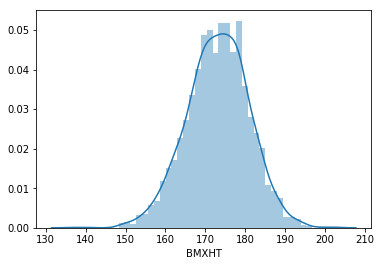

```python
# insert your code here
sns.distplot(da.BMXHT.dropna(), bins=None)
plt.show()
```

**Q3a.** Use the `bins` argument to [distplot](https://seaborn.pydata.org/generated/seaborn.distplot.html) to produce histograms with different numbers of bins. Assess whether the default value for this argument gives a meaningful result, and comment on what happens as the number of bins grows excessively large or excessively small.

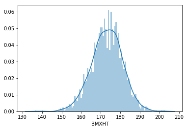

```python
# insert your code here
sns.distplot(da.BMXHT.dropna(), bins=100)
plt.show()
```

**Q3b.** Make separate histograms for the heights of women and men, then make a side-by-side boxplot showing the heights of women and men.

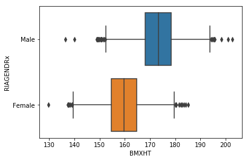

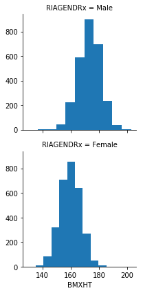

```python
da = pd.read_csv("nhanes_2015_2016.csv")
da["RIAGENDRx"] = da.RIAGENDR.replace({1: "Male", 2: "Female"})
sns.boxplot(x = da["BMXHT"], y = da["RIAGENDRx"])
g = sns.FacetGrid(da, row = "RIAGENDRx")
g = g.map(plt.hist, "BMXHT")
plt.show()
```

**Q3c.** Comment on what features, if any are not represented clearly in the boxplots, and what features, if any, are easier to see in the boxplots than in the histograms.

## Question 4

Make a boxplot showing the distribution of within-subject differences between the first and second systolic blood pressure measurents (BPXSY1 and BPXSY2).

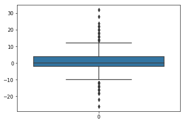

```python
# insert your code here
sns.boxplot(data=(da.BPXSY1 - da.BPXSY2))
plt.show()
```

**Q4a.** What proportion of the subjects have a lower SBP on the second reading compared to the first?

```python
# insert your code here
(da.BPXSY1 > da.BPXSY2).value_counts()
```

```
False    3272
True     2463
dtype: int64
```

**Q4b.** Make side-by-side boxplots of the two systolic blood pressure variables.

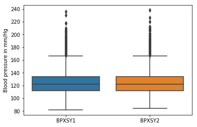

```python
# insert your code here
bp = sns.boxplot(data=da.loc[:, ["BPXSY1", "BPXSY2"]])
_ = bp.set_ylabel("Blood pressure in mm/Hg")
```

**Q4c.** Comment on the variation within either the first or second systolic blood pressure measurements, and the variation in the within-subject differences between the first and second systolic blood pressure measurements.

## Question 5

Construct a frequency table of household sizes for people within each educational attainment category (the relevant variable is DMDEDUC2). Convert the frequencies to proportions.

```python
# insert your code here
da["DMDEDUC2x"] = da.DMDEDUC2.replace({1: "Less than 9th grade", 2: "9-11th grade", 3: "High school graduate/GED or equivalent",
                                       4: "Some college or AA degree", 5: "College graduate or above",
                                       7: "Refused", 9: "Don't Know"})
da["DMDEDUC2x"] = da.DMDEDUC2x.fillna("Missing")
x = da.DMDEDUC2x.value_counts()
x / x.sum()
```

```
Some college or AA degree                 0.282650
College graduate or above                 0.238187
High school graduate/GED or equivalent    0.206800
Less than 9th grade                       0.114211
9-11th grade                              0.112119
Missing                                   0.045510
Don't Know                                0.000523
Name: DMDEDUC2x, dtype: float64
```

```python
print(da.DMDEDUC2x.value_counts().sum())
print(da.shape)
pd.isnull(da.DMDEDUC2x).sum()
```

```
5735
(5735, 30)
```

```
0
```

```python
x = da.groupby(["DMDHHSIZ"])["DMDEDUC2x"].value_counts()
x / x.sum()
```

```
DMDHHSIZ  DMDEDUC2x
1         Some college or AA degree                 0.042720
          College graduate or above                 0.034002
          High school graduate/GED or equivalent    0.031561
          9-11th grade                              0.013078
          Less than 9th grade                       0.012554
          Missing                                   0.000349
2         College graduate or above                 0.082825
          Some college or AA degree                 0.076024
          High school graduate/GED or equivalent    0.055972
          Less than 9th grade                       0.025632
          9-11th grade                              0.024935
          Missing                                   0.003836
          Don't Know                                0.000349
3         Some college or AA degree                 0.054577
          College graduate or above                 0.046207
          High school graduate/GED or equivalent    0.035397
          9-11th grade                              0.018309
          Less than 9th grade                       0.016739
          Missing                                   0.009590
4         Some college or AA degree                 0.047777
          College graduate or above                 0.039407
          High school graduate/GED or equivalent    0.033479
          9-11th grade                              0.017088
          Less than 9th grade                       0.015170
          Missing                                   0.010288
5         Some college or AA degree                 0.034525
          College graduate or above                 0.022668
          High school graduate/GED or equivalent    0.022668
          Less than 9th grade                       0.016914
          9-11th grade                              0.016391
          Missing                                   0.008544
          Don't Know                                0.000174
6         Some college or AA degree                 0.014298
          High school graduate/GED or equivalent    0.013601
          9-11th grade                              0.012729
          Less than 9th grade                       0.012380
          College graduate or above                 0.006975
          Missing                                   0.006103
7         Less than 9th grade                       0.014821
          High school graduate/GED or equivalent    0.014124
          Some college or AA degree                 0.012729
          9-11th grade                              0.009590
          Missing                                   0.006800
          College graduate or above                 0.006103
Name: DMDEDUC2x, dtype: float64
```

**Q5a.** Comment on any major differences among the distributions.

**Q5b.** Restrict the sample to people between 30 and 40 years of age. Then calculate the median household size for women and men within each level of educational attainment.

```python
# insert your code here
da[(da.RIDAGEYR >= 30) & (da.RIDAGEYR <= 40)].groupby(["DMDEDUC2x", "RIAGENDRx"])["DMDHHSIZ"].median()
```

```
DMDEDUC2x                               RIAGENDRx
9-11th grade                            Female       5.0
                                        Male         4.5
College graduate or above               Female       3.0
                                        Male         3.0
High school graduate/GED or equivalent  Female       5.0
                                        Male         4.0
Less than 9th grade                     Female       5.0
                                        Male         5.0
Some college or AA degree               Female       4.0
                                        Male         4.0
Name: DMDHHSIZ, dtype: float64
```

## Question 6

The participants can be clustered into "masked variance units" (MVU) based on every combination of the variables SDMVSTRA and SDMVPSU. Calculate the mean age (RIDAGEYR), height (BMXHT), and BMI (BMXBMI) for each gender (RIAGENDR), within each MVU, and report the ratio between the largest and smallest mean (e.g. for height) across the MVUs.

```python
# insert your code here
da.groupby(['SDMVSTRA', 'SDMVPSU', 'RIAGENDRx'])['RIDAGEYR', 'BMXHT', 'BMXBMI'].mean().unstack()
```

| SDMVSTRA | RIAGENDRx SDMVPSU | RIDAGEYR Female | RIDAGEYR Male | BMXHT Female | BMXHT Male | BMXBMI Female | BMXBMI Male |
| --- | --- | --- | --- | --- | --- | --- | --- |
| 119 | 1 | 47.663265 | 47.861111 | 159.570408 | 172.741667 | 30.052041 | 26.958333 |
|  | 2 | 52.987952 | 54.363636 | 159.244578 | 172.906818 | 27.849398 | 27.160465 |
| 120 | 1 | 43.636364 | 43.130000 | 155.402041 | 169.537755 | 32.419388 | 30.939175 |
|  | 2 | 43.736111 | 45.219178 | 159.218056 | 173.075342 | 27.400000 | 27.727397 |
| 121 | 1 | 44.397959 | 46.750000 | 158.871579 | 172.177885 | 30.856842 | 29.416505 |
|  | 2 | 44.376344 | 42.063158 | 160.229032 | 174.764516 | 26.470968 | 26.273118 |
| 122 | 1 | 42.897436 | 44.653061 | 161.315385 | 173.998969 | 29.447436 | 28.528866 |
|  | 2 | 47.333333 | 44.320000 | 157.231111 | 170.332323 | 26.611111 | 25.744444 |
| 123 | 1 | 44.841121 | 47.829787 | 162.059615 | 174.315217 | 29.905769 | 29.231522 |
|  | 2 | 46.457447 | 52.126582 | 160.476596 | 174.454430 | 30.641489 | 28.811392 |
| 124 | 1 | 51.664000 | 50.750000 | 158.788710 | 172.109009 | 29.533065 | 28.614414 |
|  | 2 | 42.541667 | 48.245614 | 162.853521 | 174.291228 | 28.640845 | 27.714035 |
| 125 | 1 | 50.900901 | 55.165289 | 160.762385 | 173.631092 | 30.385321 | 29.727731 |
|  | 2 | 51.660000 | 49.705882 | 160.021429 | 174.456863 | 28.564286 | 29.143564 |
| 126 | 1 | 46.229167 | 48.416667 | 160.387500 | 175.149398 | 31.262500 | 29.033333 |
|  | 2 | 47.205882 | 48.666667 | 160.892000 | 174.713043 | 29.612121 | 29.039130 |
| 127 | 1 | 49.694444 | 53.137931 | 157.422430 | 171.545349 | 32.189720 | 31.062353 |
|  | 2 | 51.486239 | 54.070588 | 159.022936 | 173.366667 | 30.770642 | 30.557831 |
| 128 | 1 | 55.638462 | 53.673267 | 156.339062 | 169.325000 | 32.303125 | 31.749000 |
|  | 2 | 45.589744 | 45.822785 | 160.437179 | 172.400000 | 27.491026 | 26.835443 |
| 129 | 1 | 45.329787 | 43.922222 | 156.900000 | 171.094318 | 29.019149 | 26.493182 |
|  | 2 | 43.500000 | 45.775510 | 161.034259 | 173.138298 | 29.429630 | 28.961702 |
| 130 | 1 | 47.810526 | 50.516854 | 161.977895 | 176.974157 | 30.700000 | 30.337079 |
|  | 2 | 50.833333 | 50.535354 | 160.060577 | 175.061224 | 31.490385 | 29.237755 |
| 131 | 1 | 54.893617 | 53.140187 | 161.989362 | 175.610476 | 30.061702 | 28.259615 |
|  | 2 | 45.000000 | 46.778846 | 161.673810 | 175.091346 | 32.984127 | 30.077885 |
| 132 | 1 | 43.210526 | 42.380435 | 161.508421 | 172.534066 | 29.848421 | 28.546154 |
|  | 2 | 51.700000 | 49.038760 | 159.138281 | 172.809524 | 30.540625 | 28.966667 |
| 133 | 1 | 45.105882 | 44.054795 | 158.295122 | 171.509722 | 27.959259 | 27.495833 |
|  | 2 | 47.063158 | 47.489796 | 158.627368 | 171.179167 | 29.000000 | 27.966667 |

```python
(da.groupby(['SDMVSTRA', 'SDMVPSU', 'RIAGENDRx'])['RIDAGEYR', 'BMXHT', 'BMXBMI'].max()
 /
 da.groupby(['SDMVSTRA', 'SDMVPSU', 'RIAGENDRx'])['RIDAGEYR', 'BMXHT', 'BMXBMI'].min()).unstack()
```

| SDMVSTRA | RIAGENDRx SDMVPSU | RIDAGEYR Female | RIDAGEYR Male | BMXHT Female | BMXHT Male | BMXBMI Female | BMXBMI Male |
| --- | --- | --- | --- | --- | --- | --- | --- |
| 119 | 1 | 4.444444 | 4.444444 | 1.221838 | 1.231270 | 3.256684 | 2.994413 |
|  | 2 | 4.444444 | 4.000000 | 1.267041 | 1.269385 | 4.045161 | 2.224390 |
| 120 | 1 | 4.444444 | 4.444444 | 1.254360 | 1.297715 | 3.666667 | 3.042105 |
|  | 2 | 4.444444 | 4.444444 | 1.296011 | 1.271065 | 2.443182 | 2.875000 |
| 121 | 1 | 4.444444 | 4.444444 | 1.308458 | 1.252324 | 2.538462 | 3.104938 |
|  | 2 | 4.444444 | 4.444444 | 1.249319 | 1.296036 | 3.349112 | 2.542373 |
| 122 | 1 | 4.444444 | 4.444444 | 1.232877 | 1.244646 | 3.066298 | 3.284916 |
|  | 2 | 4.444444 | 4.444444 | 1.214035 | 1.272849 | 2.730539 | 1.902703 |
| 123 | 1 | 4.444444 | 4.444444 | 1.262143 | 1.210127 | 2.483333 | 3.039548 |
|  | 2 | 4.444444 | 4.210526 | 1.237474 | 1.290116 | 2.947917 | 3.275000 |
| 124 | 1 | 4.444444 | 4.210526 | 1.259393 | 1.214700 | 3.656627 | 2.212871 |
|  | 2 | 4.444444 | 4.210526 | 1.216480 | 1.204545 | 3.530387 | 2.436464 |
| 125 | 1 | 4.444444 | 4.444444 | 1.230070 | 1.266364 | 2.948571 | 3.271605 |
|  | 2 | 4.444444 | 4.444444 | 1.248281 | 1.229072 | 3.437126 | 2.420765 |
| 126 | 1 | 4.210526 | 4.210526 | 1.223684 | 1.224347 | 3.395210 | 2.769231 |
|  | 2 | 4.444444 | 4.444444 | 1.217753 | 1.244715 | 3.226994 | 2.355670 |
| 127 | 1 | 4.444444 | 4.444444 | 1.226573 | 1.219481 | 3.195531 | 3.220930 |
|  | 2 | 4.444444 | 4.444444 | 1.267626 | 1.223082 | 3.184971 | 2.704142 |
| 128 | 1 | 4.000000 | 4.444444 | 1.277698 | 1.359029 | 3.160428 | 2.577114 |
|  | 2 | 4.444444 | 4.444444 | 1.223135 | 1.271883 | 3.434483 | 2.734940 |
| 129 | 1 | 4.444444 | 4.444444 | 1.350810 | 1.209941 | 2.806630 | 2.124324 |
|  | 2 | 4.444444 | 4.444444 | 1.245775 | 1.250484 | 3.413408 | 3.039326 |
| 130 | 1 | 4.444444 | 4.444444 | 1.227972 | 1.224691 | 3.261538 | 3.457831 |
|  | 2 | 4.000000 | 4.444444 | 1.288210 | 1.255995 | 3.875862 | 2.994475 |
| 131 | 1 | 4.444444 | 4.210526 | 1.220938 | 1.203232 | 3.444444 | 3.357616 |
|  | 2 | 4.444444 | 4.444444 | 1.203528 | 1.204759 | 3.822485 | 2.713568 |
| 132 | 1 | 4.210526 | 4.111111 | 1.198903 | 1.268568 | 3.121212 | 2.432161 |
|  | 2 | 4.444444 | 4.444444 | 1.275562 | 1.292895 | 4.078788 | 3.512195 |
| 133 | 1 | 4.444444 | 4.444444 | 1.273934 | 1.265293 | 2.969512 | 2.502762 |
|  | 2 | 4.444444 | 4.444444 | 1.202364 | 1.372161 | 3.706897 | 3.222222 |

**Q6a.** Comment on the extent to which mean age, height, and BMI vary among the MVUs.

**Q6b.** Calculate the inter-quartile range (IQR) for age, height, and BMI for each gender and each MVU. Report the ratio between the largest and smallest IQR across the MVUs.

```python
# insert your code here
max = ((da.groupby(['SDMVSTRA', 'SDMVPSU', 'RIAGENDRx'])['RIDAGEYR', 'BMXHT', 'BMXBMI'].quantile(0.75) -
 da.groupby(['SDMVSTRA', 'SDMVPSU', 'RIAGENDRx'])['RIDAGEYR', 'BMXHT', 'BMXBMI'].quantile(0.25)).max())
min = ((da.groupby(['SDMVSTRA', 'SDMVPSU', 'RIAGENDRx'])['RIDAGEYR', 'BMXHT', 'BMXBMI'].quantile(0.75) -
 da.groupby(['SDMVSTRA', 'SDMVPSU', 'RIAGENDRx'])['RIDAGEYR', 'BMXHT', 'BMXBMI'].quantile(0.25)).min())
(max - min) / min
```

```
0.75
RIDAGEYR    0.831325
BMXHT       0.623762
BMXBMI      1.865854
dtype: float64
```

**Q6c.** Comment on the extent to which the IQR for age, height, and BMI vary among the MVUs.